# Replicable Script for *Quality of Life evolution and associated factors in Multiple System Atrophy: an illustration for neurodegenerative diseases* [1]

Tiphaine Saulnier

2023-03-23

# Simulated Dataset

```r
# load data
load("data_simulated.RData")
```

This replicable script relies on a simulated sample of **300 (fictive) patients** with **10 4-level items** measured at repeated visits, and a time to event collected in continuous time.

The data.frame data is in longitudinal format with **1155 rows** corresponding to the follow-up visits of the 300 patients, and **15 columns** corresponding to the different variables:

- **ID** the patient identifier;
- **t** the time of study;
- **item*k*** the value of item k (=1,…,10) with each 4 levels (0 to 3);
- **stage** the variable indicating the disease stage with 5 levels (0 to 4);
- **T** the time of event or censoring;
- **D** the indicator of event or censoring.

Here is an overview of the dataset :

```
##   ID t item1 item2 item3 item4 item5 item6 item7 item8 item9 item10 stage    T
## 1  1 0     0     1     0     0     1     0     1     0     0      0     0 4.00
## 2  1 1     1     1     0     0     3     1     2     2     1      0     0 4.00
## 3  1 2     1     1     2     1     3     2     1     2     2      1     1 4.00
## 4  1 3     2     2     2     2     3     2     2     3     2      1     4 4.00
## 5  2 0     1     2     0     1     0     0     0     0     0      0     0 2.43
## 6  2 1     3     1     1     1     2     0     0     0     0      0     0 2.43
##   D
## 1 0
## 2 0
## 3 0
## 4 0
## 5 1
## 6 1
```

And a summary of the variables:

```
##        t         item1   item2   item3   item4   item5   item6   item7
##  Min.   :0.000   0:234   0:104   0:376   0:710   0:223   0:266   0:410
##  1st Qu.:0.000   1:659   1:636   1:444   1:319   1:133   1:224   1:220
##  Median :1.000   2:205   2:279   2:301   2: 98   2:227   2:286   2:339
##  Mean   :1.446   3: 57   3:136   3: 34   3: 28   3:572   3:379   3:186
##  3rd Qu.:2.000
##  Max.   :3.000
##  item8   item9   item10  stage
##  0:255   0:272   0:549   0:360
##  1:206   1:286   1:412   1:297
##  2:393   2:478   2:133   2:195
##  3:301   3:119   3: 61   3:196
##                          4:107
##
```

Among the patients, **117 (39%)** experienced the event during the study.

# STEP 1: identification of homogeneous sub-scale dimensions

The different dimensions measured by the scale are distinguished using the PROMIS methodology [2]. The PROMIS method aims to ensure the validity of the three calibration assumptions usually required during the statistical analysis:

- the **unidimensionality** of the items constituting a dimension,
- the **conditional independence** of the items given the underlying construct,
- the **increasing monotonicity** of each item.

PROMIS method assesses the assumptions sequentially. However, the authors recommend to make some step-backs at some points to measure the impact of some decisions and to ensure the identified dimensions make clinical sense. PROMIS technique does not handle repeated data so that we performed the first step on all the follow-ups by neglecting the intra-subject correlation.

## Unidimensionality

First, an **exploratory factorial analysis (EFA)** is performed on all the items to identify the different factors (or dimensions) measured by the scale. The optimal number of dimensions is determined according to the **scree plot** of the successive eigenvalues as the greatest number of factors with successive eigenvalues greater than value 1, or according to the Kaiser criterion [3]. This analysis can be carried out using function *fa.parallel()* from the R-package *psych* [4].

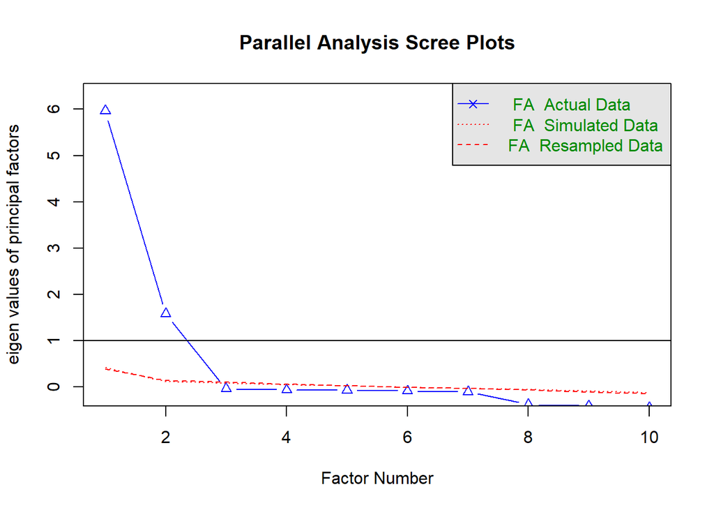

```
## Parallel analysis suggests that the number of factors =  2  and the number of components =  NA
```

```r
# screeplot
screeplot <- fa.parallel(data[,paste("item",1:K,sep="")], fm = 'minres', fa = 'fa', cor='poly')
```

The analysis suggests **2 factors**.

Then, each item is assigned to the dimension it contributes the most according to the **loadings resulting from an EFA based on the polychoric correlation matrix** [3].

```r
# polychoric correlation matrix
pc <- hetcor(data[,paste("item",1:K,sep="")], ML=TRUE)

# EFA with 2 factors
efa <- fa(r=pc$correlations, nfactors=nfact, rotate="varimax")

tab_contrib_efa <- data.frame(ITEM = paste("item",1:10,sep=""),
                              FACT1 = efa$loadings[,2],
                              FACT2 = efa$loadings[,1])
row.names(tab_contrib_efa) <- 1:K
tab_contrib_efa$CONTRIB_MAX <- apply(tab_contrib_efa[,paste("FACT",1:2,sep="")], 1, max)
tab_contrib_efa$DOMINANT_FACT <- ifelse(tab_contrib_efa$CONTRIB_MAX == tab_contrib_efa$FACT1,1,2)
tab_contrib_efa[,c("ITEM","FACT1","FACT2","DOMINANT_FACT")]
```

```
##      ITEM     FACT1     FACT2 DOMINANT_FACT
## 1   item1 0.7582483 0.1717515             1
## 2   item2 0.7677956 0.1985624             1
## 3   item3 0.7849416 0.1570398             1
## 4   item4 0.7701934 0.1349526             1
## 5   item5 0.2167163 0.7589159             2
## 6   item6 0.2177809 0.8260717             2
## 7   item7 0.2170757 0.8645252             2
## 8   item8 0.2143307 0.8461961             2
## 9   item9 0.2028239 0.8353333             2
## 10 item10 0.2251422 0.7719576             2
```

Afterwards, to confirm the previous result and to ensure the sufficient unidimensionality of the identified dimensions (i.e., items from a dimension measure the same phenomenon), a **EFA** is performed per dimension to control that the number of underlying factors is 1.

AXIS 1

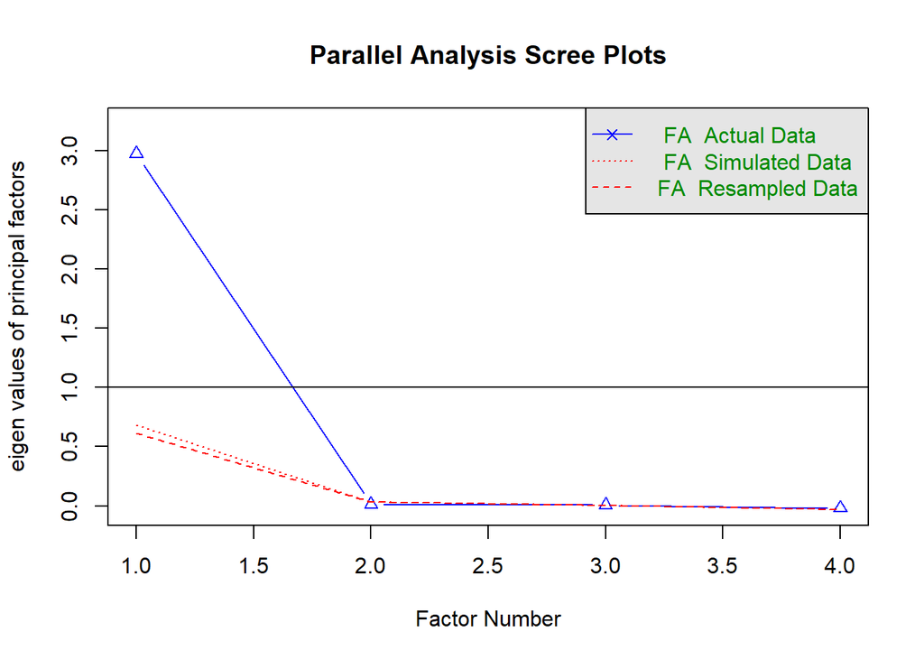

```
## Parallel analysis suggests that the number of factors =  1  and the number of components =  NA
```

The analysis concludes to **1 factor** (i.e., unidimensionality).

AXIS 2

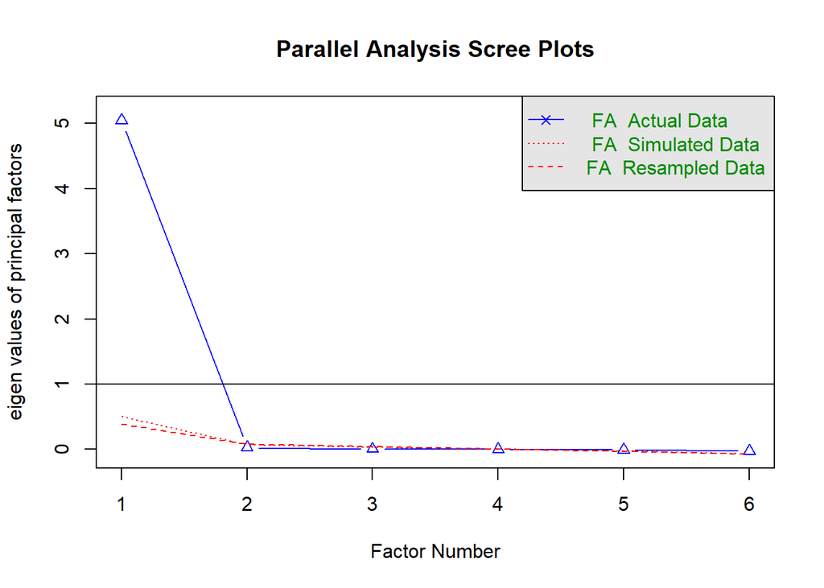

```
## Parallel analysis suggests that the number of factors =  1  and the number of components =  NA
```

The analysis concludes to **1 factor** (i.e., unidimensionality).

Then, a **confirmatory factorial analysis (CFA)** is performed to evaluate the model fit based on PROMIS recommended criteria thresholds: **comparative fit index (CFI) > 0.95**, **Tucker Lewis index (TLI) > 0.95**, **root means square error of approximation (RMSEA) < 0.06**, and **standardized root mean square residual (SRMR) < 0.08** [2,3]. This analysis can be carried out using function *cfa()* from the R-package *lavaan* [5].

```r
# CFA with 2 axes
repartition <- ' AXE1 =~ item1 + item2 + item3 + item4
                 AXE2 =~ item5 + item6 + item7 + item8 + item9 + item10'

cfa <- cfa(repartition,
           data = data,
           ordered = paste("item",1:K,sep=""))
summary(cfa, fit.measures=T)
```

```
## lavaan 0.6-11 ended normally after 29 iterations
##
##   Estimator                                       DWLS
##   Optimization method                           NLMINB
##   Number of model parameters                        41
##
##   Number of observations                          1155
##
## Model Test User Model:
##                                               Standard      Robust
##   Test Statistic                                17.241      37.640
##   Degrees of freedom                                34          34
##   P-value (Chi-square)                           0.992       0.306
##   Scaling correction factor                                  0.611
##   Shift parameter                                            9.409
##        simple second-order correction
##
## Model Test Baseline Model:
##
##   Test statistic                             75913.327   34090.386
##   Degrees of freedom                                45          45
##   P-value                                        0.000       0.000
##   Scaling correction factor                                  2.228
##
## User Model versus Baseline Model:
##
##   Comparative Fit Index (CFI)                    1.000       1.000
##   Tucker-Lewis Index (TLI)                       1.000       1.000
##
##   Robust Comparative Fit Index (CFI)                            NA
##   Robust Tucker-Lewis Index (TLI)                               NA
##
## Root Mean Square Error of Approximation:
##
##   RMSEA                                          0.000       0.010
##   90 Percent confidence interval - lower         0.000       0.000
##   90 Percent confidence interval - upper         0.000       0.024
##   P-value RMSEA <= 0.05                          1.000       1.000
##
##   Robust RMSEA                                                  NA
```

[output cut: 93 more lines]

```
##     AXE1              0.713    0.026   27.251    0.000
##     AXE2              0.796    0.018   43.899    0.000
##
## Scales y*:
##                    Estimate  Std.Err  z-value  P(>|z|)
##     item1             1.000
##     item2             1.000
##     item3             1.000
##     item4             1.000
##     item5             1.000
##     item6             1.000
##     item7             1.000
##     item8             1.000
##     item9             1.000
##     item10            1.000
```

## Local independence

To ensure the conditional independence (i.e., items from the same dimension do not carry redundant information), the **residual correlation matrix** between the CFA fitted values and the observed items values of each dimension is computed. PROMIS authors consider that the assumption is not satisfied for a residual correlation **greater than 0.2** between two items, and recommend, in the case, to remove one of them.

```r
N_cov <- list(
  observed=inspect(cfa, 'sampstat')$cov,
  fitted=fitted(cfa)$cov
)

N_cor <- list(
  observed=cov2cor(N_cov$observed),
  fitted=cov2cor(N_cov$fitted)
)

N_cor$residuals <- N_cor$observed - N_cor$fitted

N_cor <- lapply(N_cor, function(X) round(X, 2))

N_cor$residuals
```

```
##        item1 item2 item3 item4 item5 item6 item7 item8 item9 item10
## item1   0.00
## item2  -0.01  0.00
## item3   0.01 -0.01  0.00
## item4  -0.01  0.00  0.02  0.00
## item5   0.03  0.02  0.01  0.03  0.00
## item6   0.01  0.02 -0.01  0.00  0.00  0.00
## item7   0.00  0.01 -0.04 -0.01  0.00  0.00  0.00
## item8   0.02  0.03 -0.04 -0.02  0.00  0.00  0.00  0.00
## item9  -0.02  0.00 -0.02 -0.04  0.00  0.00  0.00  0.00  0.00
## item10  0.01  0.01 -0.02 -0.02 -0.02  0.00  0.00  0.00  0.01  0.00
```

```r
Ncor_bin <- (N_cor$residuals > 0.2 | N_cor$residuals < -0.2)
Ncor_bin[upper.tri(Ncor_bin,diag=F)] <- NA
print(Ncor_bin,quote=FALSE,na.print="")
```

```
##        item1 item2 item3 item4 item5 item6 item7 item8 item9 item10
## item1  FALSE
## item2  FALSE FALSE
## item3  FALSE FALSE FALSE
## item4  FALSE FALSE FALSE FALSE
## item5  FALSE FALSE FALSE FALSE FALSE
## item6  FALSE FALSE FALSE FALSE FALSE FALSE
## item7  FALSE FALSE FALSE FALSE FALSE FALSE FALSE
## item8  FALSE FALSE FALSE FALSE FALSE FALSE FALSE FALSE
## item9  FALSE FALSE FALSE FALSE FALSE FALSE FALSE FALSE FALSE
## item10 FALSE FALSE FALSE FALSE FALSE FALSE FALSE FALSE FALSE  FALSE
```

```r
table(Ncor_bin)
```

```
## Ncor_bin
## FALSE
##    55
```

Here, no redundancy is observed.

## Increasing monotonicity

To ensure the increasing monotonocity (i.e., higher levels of items always correspond to higher levels of impairment), a non-parametric IRT model is run for each dimension using function *check.monotonicity()* from R-package *mokken* [6]. It permits to compute the **probabilities of endorsing a higher level** for each item and to predict the item level to be compared to the increasing dimension sumscores (excepting the considered item score) through plots. According to the authors, the item response curves should be increasing, or, at least, constant.

AXIS 1

```r
check.mono.axe1 <- check.monotonicity(data[,paste("item",1:4,sep="")], minsize=100)
summary(check.mono.axe1)
```

```
##       ItemH #ac #vi #vi/#ac maxvi sum sum/#ac zmax #zsig crit
## item1  0.75  26   0       0     0   0       0    0     0    0
## item2  0.74  27   0       0     0   0       0    0     0    0
## item3  0.76  21   0       0     0   0       0    0     0    0
## item4  0.74  25   0       0     0   0       0    0     0    0
```

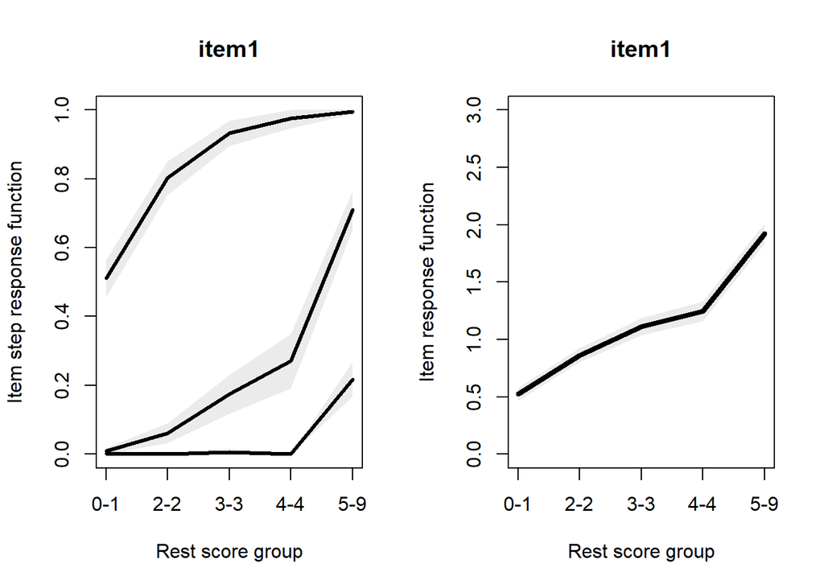

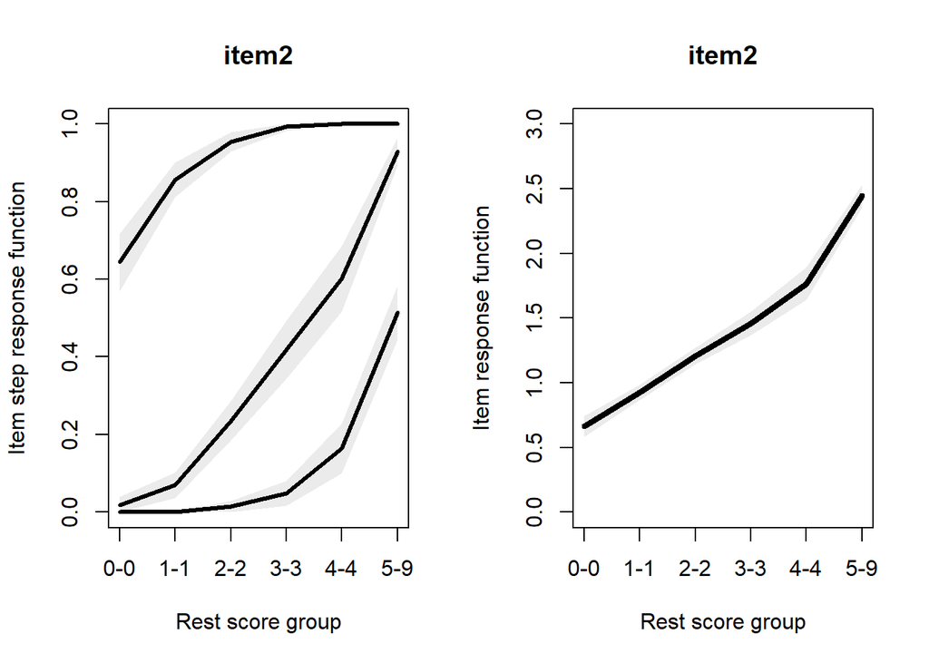

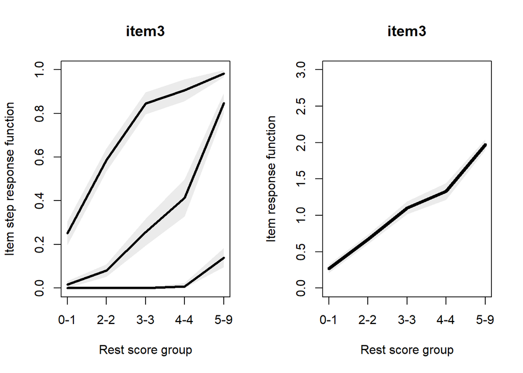

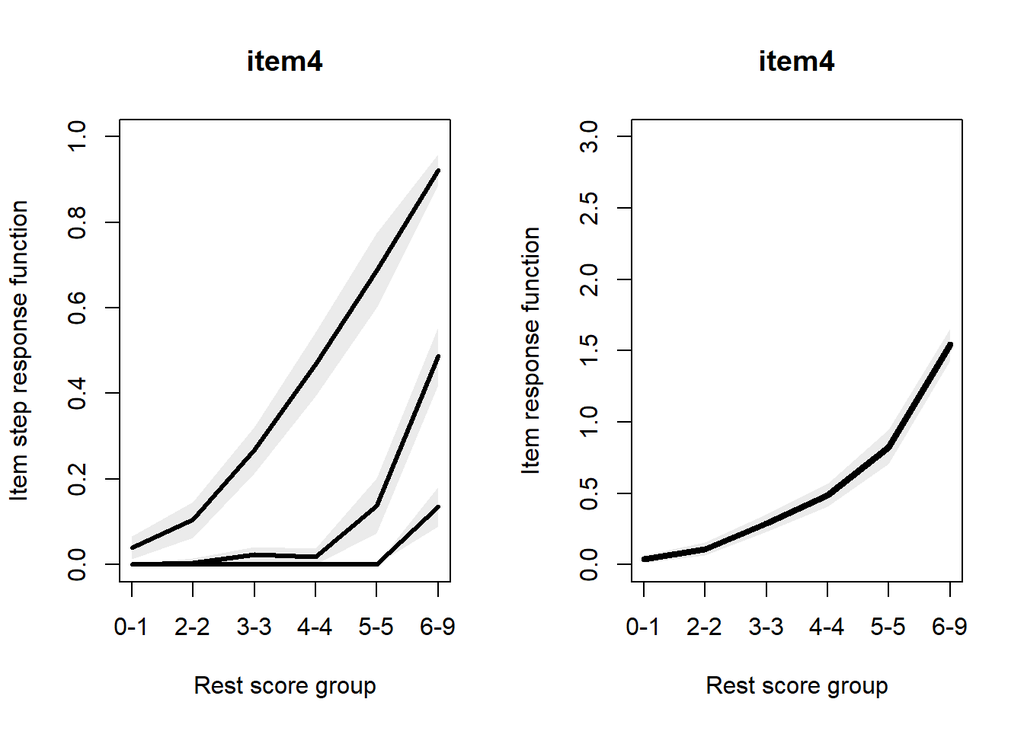

```r
plot(check.mono.axe1)
```

AXIS 2

```r
check.mono.axe2 <- check.monotonicity(data[,paste("item",5:K,sep="")], minsize=100)
summary(check.mono.axe2)
```

```
##        ItemH #ac #vi #vi/#ac maxvi sum sum/#ac zmax #zsig crit
## item5   0.78  53   0       0     0   0       0    0     0    0
## item6   0.80  57   0       0     0   0       0    0     0    0
## item7   0.83  42   0       0     0   0       0    0     0    0
## item8   0.81  46   0       0     0   0       0    0     0    0
## item9   0.80  46   0       0     0   0       0    0     0    0
## item10  0.84  35   0       0     0   0       0    0     0    0
```

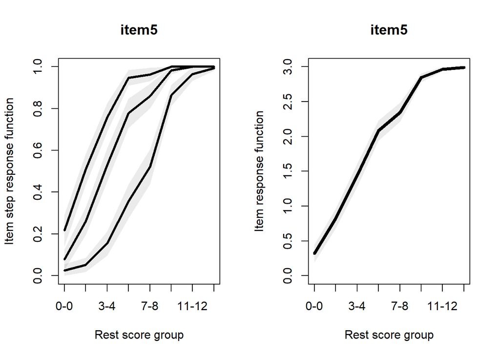

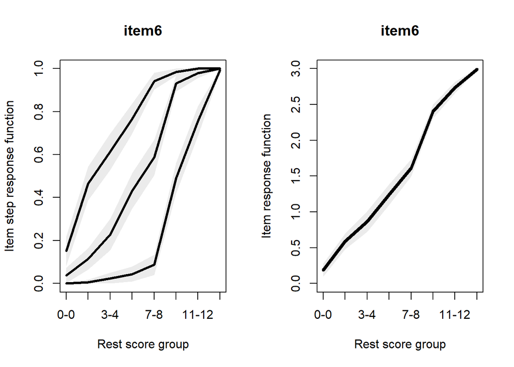

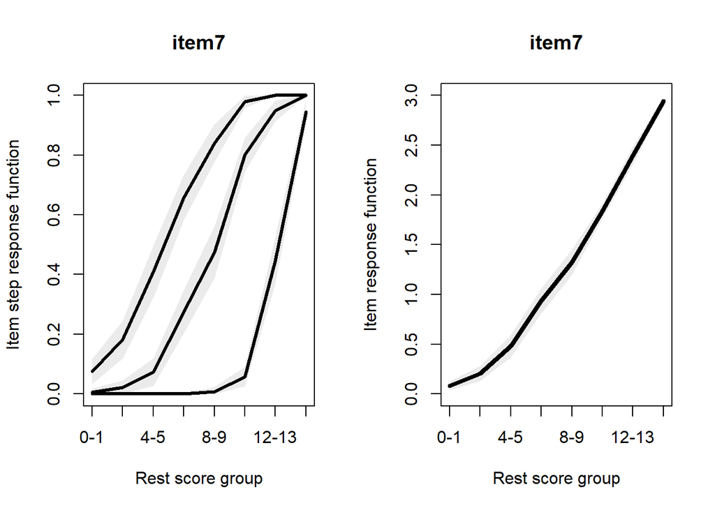

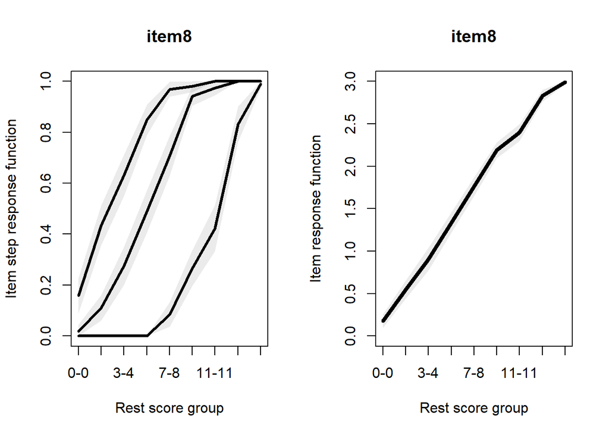

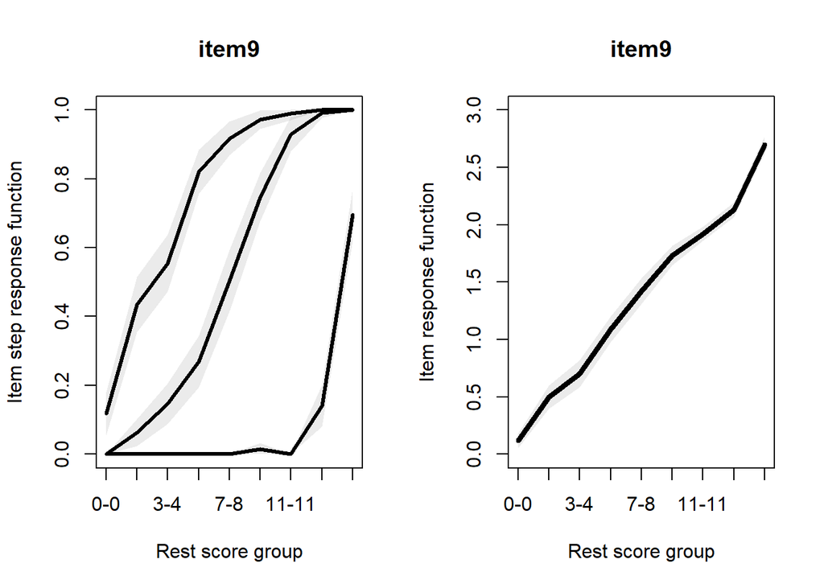

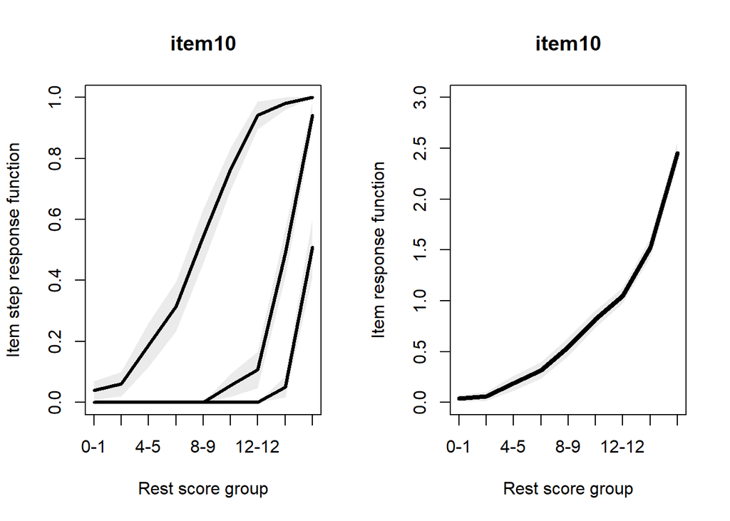

```r
plot(check.mono.axe2)
```

At this stage, each homogenous sub-scale is identified and can be analyzed separately in steps 2 to 4.

In this script, steps 2 to 4 are illustrated below on AXE 1 only.

# STEP 2: description of items’ trajectories over time and associated factors

The trajectory of each dimension continuum was modeled over time from the repeated item data using a **joint Item Response Theory (IRT) model** adapted to ordinal repeated measures and time-to-event data [7]. The model is composed of a longitudinal submodel and a survival submodel simultaneously estimated by maximum likelihood in the R-package *JLPM* (available on CRAN [8] and https://github.com/VivianePhilipps/JLPM).

The longitudinal submodel combines:

1. a linear mixed structural model to describe the underlying dimension deterioration over time according to covariates and functions of time, the fixed effects defining the mean dimension trajectory at the population level and individual correlated random effects capturing individual deviations;
2. an item-specific cumulative probit measurement model to define the link between the underlying dimension and each item observation.

The survival submodel is a proportional hazard survival model adjusted on the current underlying dimension level as a linear predictor to account for the informative dropout induced by deaths. For further details, please refer to Saulnier et al. [7].

#### Estimation

```r
# (optional) initial values
B <- c(0.4472136,2.2360680,0.1, #survival submodel
       1, #fixed effects
       0,0.2, #random effects
       0,1.7320508,1.4142136, #item thresholds
       -1,1.7320508,1.4142136,
       0.5,1.4142136,1.7320508,
       2,1.4142136,1.4142136,
       1,1,1,1) #measurement errors

# model estimation
M_AXE1 <- jointLPM(fixed = item1 + item2 + item3 + item4 ~ t,
                   random = ~ 1 + t,
                   survival = Surv(T, D) ~ 1,
                   sharedtype = "CL",
                   var.time = "t",
                   subject = "ID",
                   data = data,
                   link = "thresholds",
                   methInteg = "QMC",
                   B = B,
                   nMC = 1000,
                   nproc = 5)
```

```r
summary(M_AXE1)
```

```
## Joint latent process model with shared random effects
##      fitted by maximum likelihood method
##
## jointLPM(fixed = item1 + item2 + item3 + item4 ~ t, random = ~1 +
##     t, subject = "ID", link = "thresholds", var.time = "t", survival = Surv(T,
##     D) ~ 1, sharedtype = "CL", methInteg = "QMC", nMC = 1000,
##     data = data, nproc = 5)
##
## Statistical Model:
##      Dataset: data
##      Number of subjects: 300
##      Number of observations: 4620
##      Number of parameters: 22
##      Event 1 :
##         Number of events: 117
##         Weibull baseline risk function
##      Link functions: Thresholds for item1
##                      Thresholds for item2
##                      Thresholds for item3
##                      Thresholds for item4
##
## Iteration process:
##      Convergence criteria satisfied
##      Number of iterations:  5
##      Convergence criteria: parameters= 6.6e-06
##                          : likelihood= 6.3e-05
##                          : second derivatives= 3e-10
##
## Goodness-of-fit statistics:
##      maximum log-likelihood: -3720.83
##      AIC: 7485.65
##      BIC: 7567.13
##
## Maximum Likelihood Estimates:
##
##
## Parameters in the proportional hazard model:
##
##
##                              coef      Se   Wald p-value
```

[output cut: 20 more lines]

```
## Parameters of the link functions:
##
##                   coef      Se   Wald p-value
## item1-Thresh1 -0.25155 0.09015 -2.790 0.00527
## item1-Thresh2  1.80732 0.06058 29.835 0.00000
## item1-Thresh3  1.46267 0.06501 22.499 0.00000
## item2-Thresh1 -1.09806 0.11628 -9.444 0.00000
## item2-Thresh2  1.79242 0.05811 30.845 0.00000
## item2-Thresh3  1.37365 0.05563 24.693 0.00000
## item3-Thresh1  0.48697 0.08541  5.702 0.00000
## item3-Thresh2  1.42606 0.05061 28.176 0.00000
## item3-Thresh3  1.77894 0.07345 24.218 0.00000
## item4-Thresh1  1.98890 0.14431 13.782 0.00000
## item4-Thresh2  1.45578 0.05893 24.705 0.00000
## item4-Thresh3  1.36299 0.07760 17.565 0.00000
```

## Graph representing items’ evolution according to time

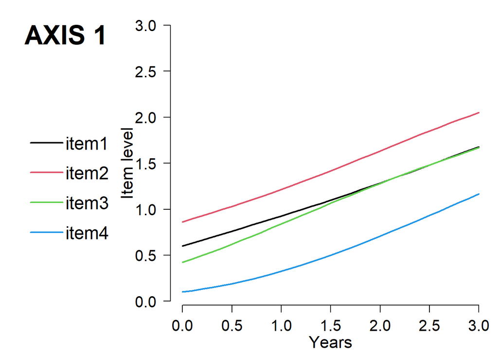

```r
K.1 <- 4

### PREDICTION
M_AXE1$call$nproc <- NULL
M_AXE1_multlcmm <- convert(object = M_AXE1, to = "multlcmm")
prediction <- predictY(x = M_AXE1_multlcmm,
                       newdata = data.frame(t = seq(from = 0, to = 3, by = 0.1)),
                       var.time = "t",
                       methInteg = 1, # simus by MonteCarlo
                       nsim = 1000, # nb simus
                       draws = F) # for IC


### GRAPH
par(mar=c(3,12,1,0.5))

plot(x = prediction$times$t, y = prediction$pred$Ypred[which(prediction$pred$Yname == "item1")], col = 1, lwd = 2,
     type = "l", xlim = c(0,3), ylim = c(0,3),
     bty="n",axes=F,xlab="",ylab="")
for(k in 2:K.1){
  lines(x = prediction$times$t, y = prediction$pred$Ypred[which(prediction$pred$Yname == paste("item",k,sep=""))], col = k, lwd = 2, type = "l")
}
axis(2,line=0, lwd=1,cex.axis=1.3, las=1)
mtext(text = "Item level", cex = 1.4, side = 2, line = 2.5)

axis(1,line=-0.5, cex.axis=1, lwd=1,cex.axis=1.3)
mtext(text = "Years", cex = 1.4, side = 1, line = 1.7)

par(xpd=TRUE)
legend(x = -1.7, y = 2, lty = 1, lwd = 2, col = 1:K.1,
       legend = paste("item",1:K.1,sep=""),
       bty = "n", cex = 1.5, y.intersp=1.4, x.intersp=0.2)

par(xpd=TRUE)
text(x = -1.6, y = 2.9,
     labels = "AXIS 1", cex = 2.25, col = 1, adj = 0, font = 2)
```

## Graph representing items’ degradation hierarchy

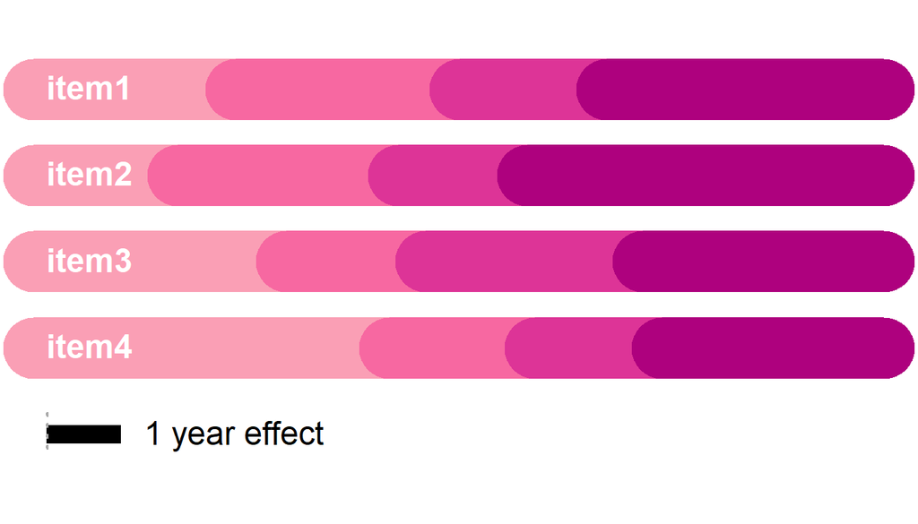

```r
nl <- 4 #nb of level per item
### THRESHOLDS
B_threshold <- M_AXE1$best[7:18]
threshold <- as.data.frame(matrix(B_threshold,nrow=nl-1,ncol=K.1,byrow=F))
names(threshold) <- paste("item",1:K.1,sep="")
threshold$level <- c("0 -> 1","1 -> 2","2 -> 3")
threshold <- threshold[c("level",paste("item",1:K.1,sep=""))]
for(i in 2:(nl-1))
  threshold[i,-1] <- threshold[i-1,-1] + threshold[i,-1]^2
threshold_boundaries <- c(-3,7) # c(min(threshold[1,-1]),max(threshold[3,-1]))

### GRAPH

color_axe <- brewer.pal(9, "RdPu") # purple for axe 1

par(mar = c(2,0,2,0))

plot(y = rep(K.1,2), x = c(threshold_boundaries[1]-0.2,threshold[1,"item1"]), lwd = 45, type = "l", col = color_axe[4],
     xlim = c(threshold_boundaries[1]-0.2, threshold_boundaries[2]+0.2+2), ylim = c(-0.25, 4.25),
     xlab = "", ylab = "", yaxt = "n", bty = "l", legend = NULL, cex.lab=1.5, cex.axis=1.5, axes = F)
l <- 0
for(k in 1:K.1){
  lines(y = rep(K.1-l,2), x = c(threshold_boundaries[1]-0.2,threshold[1,paste("item",k,sep="")]), lwd = 45, col = color_axe[4])
  lines(y = rep(K.1-l,2), x = threshold[1:2,paste("item",k,sep="")], lwd = 45, col = color_axe[5])
  lines(y = rep(K.1-l,2), x = threshold[2:3,paste("item",k,sep="")], lwd = 45, col = color_axe[6])
  lines(y = rep(K.1-l,2), x = c(threshold[3,paste("item",k,sep="")],threshold_boundaries[2]+0.2+2), lwd = 45, col = color_axe[7])
  l <- l+1
}
text(x = threshold_boundaries[1] - 0.2, y = K.1:1, pos = 4, labels=paste("item",1:K.1,sep=""), cex=1.5, col="white", font=2)

## varexp
rect(xleft = threshold_boundaries[1], xright = threshold_boundaries[1]+M_AXE1$best[4], ybottom = -0.1, ytop = 0.1, col = "black") # time effect
lines(x = rep(threshold_boundaries[1],2), y = c(0.25,-0.25), lty = 3, lwd = 2, col = "darkgrey")
text(x = threshold_boundaries[1] + M_AXE1$best[4] + 0.15, y = 0, pos = 4, labels="1 year effect",cex=1.5)
```

# STEP 3: mapping of item impairment hierarchy to disease stages

The disease stages are projected onto a dimension continuum using a **joint bivariate model** to link the disease stages to the dimension total sumscore. This can be performed using the R-package *JLPM* [8], also adapted to treat continuous markers by replacing the cumulative probit measurement models by linear and curvilinear measurement models (the curvilinear model involves a parameterized bijective link function approximated by splines which captures the departure from normality of the variable) [7]. Then, thresholds in the dimension continuum corresponding to each disease stage can be deduced by **predicting the dimension sumscores that correspond to a change of disease stage and expressing them in the dimension process scale**. Note that, as this part requires the computation of dimension sumscores, it doesn’t handled missing data.

## Model with stage variable/outcome

```r
# score variable
data$score_AXE1 <- rowSums(data[,paste("item",1:K.1,sep="")])
```

```r
# (optional) initial values
B <- c(0.4472136,2.2360680,0, #survival submodel
       1, #fixed effects
       0,0.2, #random effects
       -2,0.1,0.1,0.1,0.1, #score spline parameters
       0.25,1.1180340,1,1.2247449, #stage thresholds
       1,1) #measurement errors

# model estimation
M_AXE1_stage <- jointLPM(fixed = score_AXE1 + stage ~ t,
                         random = ~ 1 + t,
                         survival = Surv(T, D) ~ 1,
                         sharedtype = "CL",
                         var.time = "t",
                         subject = "ID",
                         data = data,
                         link = c("3-quant-splines","thresholds"),
                         methInteg = "QMC",
                         B = B,
                         nMC = 1000,
                         nproc = 5)
```

```r
summary(M_AXE1_stage)
```

```
## Joint latent process model with shared random effects
##      fitted by maximum likelihood method
##
## jointLPM(fixed = score_AXE1 + stage ~ t, random = ~1 + t, subject = "ID",
##     link = c("3-quant-splines", "thresholds"), var.time = "t",
##     survival = Surv(T, D) ~ 1, sharedtype = "CL", methInteg = "QMC",
##     nMC = 1000, data = data, nproc = 5)
##
## Statistical Model:
##      Dataset: data
##      Number of subjects: 300
##      Number of observations: 2310
##      Number of parameters: 17
##      Event 1 :
##         Number of events: 117
##         Weibull baseline risk function
##      Link functions: Quadratic I-splines with nodes 0 3 12 for score_AXE1
##                      Thresholds for stage
##
## Iteration process:
##      Convergence criteria satisfied
##      Number of iterations:  16
##      Convergence criteria: parameters= 3.4e-10
##                          : likelihood= 2e-09
##                          : second derivatives= 1.5e-14
##
## Goodness-of-fit statistics:
##      maximum log-likelihood: -4035.23
##      AIC: 8104.46
##      BIC: 8167.43
##
## Maximum Likelihood Estimates:
##
##
## Parameters in the proportional hazard model:
##
##
##                              coef      Se    Wald p-value
## event1 +/-sqrt(Weibull1)  0.45113 0.01407  32.053 0.00000
## event1 +/-sqrt(Weibull2)  2.11036 0.10281  20.527 0.00000
```

[output cut: 15 more lines]

```
##
## Residual standard error:  0.85142  4.08446
##
## Parameters of the link functions:
##
##                           coef      Se    Wald p-value
## score_AXE1-I-splines1 -2.04997 0.15783 -12.989 0.00000
## score_AXE1-I-splines2  1.15995 0.06032  19.229 0.00000
## score_AXE1-I-splines3  2.02875 0.08149  24.897 0.00000
## score_AXE1-I-splines4 -1.14985 0.15420  -7.457 0.00000
## score_AXE1-I-splines5  1.76963 0.11836  14.951 0.00000
## stage-Thresh1         -0.50702 0.24157  -2.099 0.03583
## stage-Thresh2          1.73299 0.09474  18.292 0.00000
## stage-Thresh3          1.44830 0.08439  17.162 0.00000
## stage-Thresh4          1.76556 0.10251  17.223 0.00000
```

## Graph representing sumscore and stage predictions in the latent scale

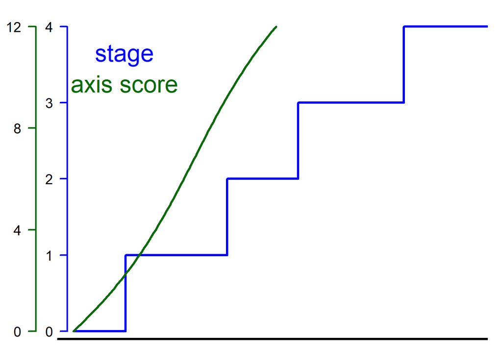

```r
### CONVERSION JLPM -> MULTLCMM for estimlink
M_AXE1_stage$call$nproc <- NULL
M_AXE1_stage_multlcmm <- convert(object = M_AXE1_stage, to = "multlcmm")


### GRAPH
par(mar=c(1,4,1,1))

# stage
plot(x = M_AXE1_stage_multlcmm$estimlink[1:10,"transfstage"], y = M_AXE1_stage_multlcmm$estimlink[1:10,"stage"], col = "blue", type = "s", lwd = 3,
     xlim = c(M_AXE1_stage_multlcmm$estimlink[1,"transfstage"],M_AXE1_stage_multlcmm$estimlink[9,"transfstage"]+2), ylim = c(0,4), bty="n",axes=F,xlab="",ylab="")
axis(2,col="blue",line=-.7,las=1,cex.axis=1.2, lwd = 2)

# axe x
abline(h = -0.1, lwd = 3, col = "black")

# score axe
par(new = T)
plot( x = M_AXE1_stage_multlcmm$estimlink[,"transfscore_AXE1"], y = M_AXE1_stage_multlcmm$estimlink[,"score_AXE1"],
      col = "#096A09", type = "l", lwd = 3,
      xlim = c(min(M_AXE1_stage_multlcmm$estimlink[,"transfstage"]),max(M_AXE1_stage_multlcmm$estimlink[,"transfstage"]+2)), ylim = c(0,12), xlab = "", ylab = "", bty = "n", axes = FALSE)
axis(2,at=c(0,4,8,12),col="#096A09",line=1.5,las=1,cex.axis=1.2, lwd = 2)

# legend
legend(x=M_AXE1_stage_multlcmm$estimlink[1,"transfstage"]+0.4,y=12,adj=.5,bg="transparent",legend=c("stage","axis score"),cex=2,text.col=c("blue","#096A09"),box.lty=0)
```

## Graph representing items’ degradation hierarchy during stages

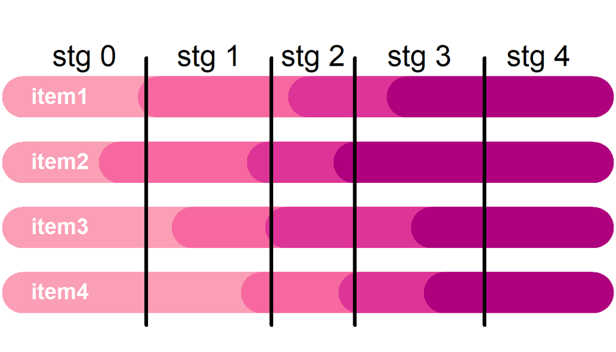

```r
### PREDICTION OF THE STAGE THRESHOLDS IN THE LATENT SCALE OF AXE 1
threshold_stage <- M_AXE1_stage$best[c("Thresh1","Thresh2","Thresh3","Thresh4")]
threshold_stage[2] <- threshold_stage[1] + threshold_stage[2]^2
threshold_stage[3] <- threshold_stage[2] + threshold_stage[3]^2
threshold_stage[4] <- threshold_stage[3] + threshold_stage[4]^2
discrim <- 1 / as.numeric(M_AXE1$best[paste("std.err ",1:K.1,sep="")])


################################################################################
# function
threshold_in_latent_scale <- function(thres.stg,data,B.stg_multlcmm,ni,nl,thres.item,discrim.item){

  #####
  ### predict the score of the axe corresponding to stagechanges
  #####

  M.stg_multlcmm <- multlcmm(fixed = score_AXE1 ~ t,
                             random = ~ t,
                             subject = "ID",
                             data = data,
                             link = "3-quant-splines",
                             methInteg = "QMC",
                             nMC = 1000,
                             B = B.stg_multlcmm,
                             maxiter = 0,
                             verbose = FALSE)
  Y_thres.stg <- predictYcond(x = M.stg_multlcmm,lprocess = thres.stg,nsim=500)$pred$Ypred

  #####
  ### conditional expectancy to deduct thresholds in the latent scale of the axe
  #####

  # compute pultiple values of the latent scale
  tmp <- data.frame(lambda = seq(from = -10, to = 10, by = 0.001))
  tmp$sum <- sapply(X = tmp$lambda, FUN = expect, ni=ni, nl=nl, discrim = discrim.item, thres = thres.item)

  # lambda as score == sum of items
  res <- rep(NA,length(thres.stg))
  for(j in 1:length(thres.stg))
    res[j] <- tmp$lambda[which(abs(tmp$sum - Y_thres.stg[j]) == min(abs(tmp$sum - Y_thres.stg[j])))]
  res

  return(res)
}

# sub-function of the conditional expectancy: E[sum(Y)] = sum_k{nl - sum(P(Yk<=m))_m=0,...,nl-1}
expect <- function(lambda, ni, nl, discrim, thres){

  proba <- matrix(NA,nrow=nl-1,ncol=ni) # matrix of probas P(Y<=m) with m=0,1,2,..,(nl-2)
  for(k in 1:ni)
    for(l in 1:(nl-1))
      proba[l,k] <- pnorm(-discrim[k]*(lambda-thres[l,k]))

  probaSum <- colSums(proba)
  probaSum <- sum(probaSum)

  res <- ni*(nl-1) - probaSum

  return(res)
}
################################################################################

lambda.stg.in.axe1 <- threshold_in_latent_scale(thres.stg = threshold_stage, data = data,
                          B.stg_multlcmm = M_AXE1_stage_multlcmm$best[c("t","varcov 1","varcov 2","std.err 1","I-splines1","I-splines2","I-splines3","I-splines4","I-splines5")],
                          ni = 4, nl = 4, thres.item = threshold[,-1], discrim.item = discrim)



### GRAPH
par(mar = c(0,0,4,0))

# items
plot(y = rep(K.1,2), x = c(threshold_boundaries[1]-0.2,threshold[1,"item1"]), lwd = 45, type = "l", col = color_axe[4],
     xlim = c(threshold_boundaries[1]-0.2, threshold_boundaries[2]+0.2+2), ylim = c(0.25, 4.25),
     xlab = "", ylab = "", yaxt = "n", bty = "l", legend = NULL, cex.lab=1.5, cex.axis=1.5, axes = F)
l <- 0
for(k in 1:K.1){
  lines(y = rep(K.1-l,2), x = c(threshold_boundaries[1]-0.2,threshold[1,paste("item",k,sep="")]), lwd = 45, col = color_axe[4])
  lines(y = rep(K.1-l,2), x = threshold[1:2,paste("item",k,sep="")], lwd = 45, col = color_axe[5])
  lines(y = rep(K.1-l,2), x = threshold[2:3,paste("item",k,sep="")], lwd = 45, col = color_axe[6])
  lines(y = rep(K.1-l,2), x = c(threshold[3,paste("item",k,sep="")],threshold_boundaries[2]+0.2+2), lwd = 45, col = color_axe[7])
  l <- l+1
}
text(x = threshold_boundaries[1]-0.2, y = K.1:1, pos = 4, labels=paste("item",1:K.1,sep=""), cex=1.5, col="white", font=2)

#stages
par(xpd=TRUE)
for(j in 1:length(lambda.stg.in.axe1))
  lines(x = rep(lambda.stg.in.axe1[j],2), y = c(.5,K.1+0.6), lwd = 4, col = "black")
text(y = K.1+0.6,
     x = c((lambda.stg.in.axe1[1]-(threshold_boundaries[1]-0.2))/2+(threshold_boundaries[1]-0.2),
           (lambda.stg.in.axe1[2]-lambda.stg.in.axe1[1])/2+lambda.stg.in.axe1[1],
           (lambda.stg.in.axe1[3]-lambda.stg.in.axe1[2])/2+lambda.stg.in.axe1[2],
           (lambda.stg.in.axe1[4]-lambda.stg.in.axe1[3])/2+lambda.stg.in.axe1[3],
           ((threshold_boundaries[2]+0.2+2)-lambda.stg.in.axe1[4])/2+lambda.stg.in.axe1[4]),
     labels = paste("stg ",0:4,sep=""), cex = 2, col = "black")
```

# STEP 4: Most informative items by disease stage

## Fisher information table

```r
### FISHER INFORMATION COMUTATION

################################################################################
# function to compute the Fisher information carried by items during stages
fisher_information <- function(thres,discrim,ni,nl,ns,lambda.s){

  ### info brut
  info <- matrix(NA, ncol = ns, nrow = ni)

  for(i in 1:ni){ # item i

    for(s in 1:ns){ # stage s

      ##boundaries of stage s
      if(s == 1){ # first stage
        lambda.s.inf <- -Inf
        lambda.s.sup <- lambda.s[1]
      }
      if(s == ns){ # last stage
        lambda.s.inf <- lambda.s[ns-1]
        lambda.s.sup <- +Inf
      }
      if(s != 1 && s != ns){ # other stages
        lambda.s.inf <- lambda.s[s-1]
        lambda.s.sup <- lambda.s[s]
      }

      E1 <- 0 #first element = sum_i(integral)
      E2 <- 0 # second element = sum_i(subtraction)
      for(m in 0:(nl-1)){ # level m
        E1 <- E1 + integrate(f=fct_to_integrate,lower=lambda.s.inf,upper=lambda.s.sup,i,thres,discrim,m,nl)$value
        E2 <- E2 + Pim.prime(lambda=lambda.s.sup,i,thres,discrim,m,nl) - Pim.prime(lambda=lambda.s.inf,i,thres,discrim,m,nl)
      }

      info[i,s] <- E1 - E2

    }

  }

  ### info in %
  percent <- info
  for(i in 1:ni)
    percent[i,] <- percent[i,] / colSums(info)
  percent <- percent * 100
  colSums(percent) # verif == 100 ?

 res <- list(info,percent)

 return(res)

}

#####
### function proba P : Pim(lambda) = P(Yi = m |lambda)
#####
Pim <- function(lambda,
                i,thres,discrim,
                m,nl){

  res <- NA

  discrim_i <- discrim[i]

  # m=0, smaller level
  if(m == 0){
    thres.im <- thres[1,i]
    res <- pnorm(-discrim_i * (lambda - thres.im))
  }

  # m=nl-1, higher level
  if(m == (nl-1)){
    thres.im <- thres[nl-1,i]
    res <- 1 - pnorm(-discrim_i * (lambda - thres.im))
  }

  # other levels
  if(m != 0 && m!=(nl-1)){
    thres.im.inf <- thres[m,i]
    thres.im.sup <- thres[m+1,i]
    res <- pnorm(-discrim_i * (lambda - thres.im.sup)) - pnorm(-discrim_i * (lambda - thres.im.inf))
  }

  return(res)

}

#####
### function first derive P' : P'im(lambda) = dPim(lambda) / dlambda
#####
Pim.prime <- function(lambda,
                      i,thres,discrim,
                      m,nl){

  res <- NA

  discrim_i <- discrim[i]

  # m=0, smaller level
  if(m == 0){
    thres.im <- thres[1,i]
    res <- -discrim_i * dnorm(-discrim_i*(lambda - thres.im))
  }

  # m=nl-1, higher level
  if(m == (nl-1)){
    thres.im <- thres[nl-1,i]
    res <- discrim_i * dnorm(-discrim_i * (lambda - thres.im))
  }

  # other levels
  if(m != 0 && m!=(nl-1)){
    thres.im.inf <- thres[m,i]
    thres.im.sup <- thres[m+1,i]
    res <- -discrim_i * dnorm(-discrim_i * (lambda - thres.im.sup)) + discrim_i * dnorm(-discrim_i * (lambda - thres.im.inf))
  }

  return(res)

}

#####
### function to integrate : (P'im)^2 / Pim between boundaries corresponding to stage s
#####
fct_to_integrate <- function(lambda,
                             i,thres,discrim,
                             m,nl){

  res <- Pim.prime(lambda,i,thres,discrim,m,nl)^2
  denom <- Pim(lambda,i,thres,discrim,m,nl)
  res <- ifelse(denom == 0,
                res <- 0,
                res <- res / denom)
  return(res)

}
################################################################################

fisher <- fisher_information(thres = threshold[,-1], discrim = discrim, ni = K.1, nl = nl, ns = 5, lambda.s = lambda.stg.in.axe1)
dimnames(fisher[[1]]) <- list(paste("item",1:K.1,sep=""),paste("stage",0:4,sep=""))
dimnames(fisher[[2]]) <- list(paste("item",1:K.1,sep=""),paste("stage",0:4,sep=""))
names(fisher) <- c("raw.information","percentage")

fisher
```

```
## $raw.information
##             stage0    stage1    stage2   stage3       stage4
## item1 0.1255602987 1.2418927 0.9895219 1.322511 4.752799e-03
## item2 0.3925308648 1.4056587 1.2228116 0.864327 1.964106e-05
## item3 0.0264896844 1.7206819 1.0227370 1.459383 1.745578e-02
## item4 0.0001974107 0.9276838 1.1045962 1.663315 3.967822e-02
##
## $percentage
##            stage0   stage1   stage2   stage3      stage4
## item1 23.04796433 23.45000 22.80180 24.90822  7.67739027
## item2 72.05332787 26.54231 28.17755 16.27877  0.03172701
## item3  4.86247092 32.49073 23.56718 27.48608 28.19703663
## item4  0.03623689 17.51696 25.45348 31.32694 64.09384609
```

## Graph representing item contribution to stages

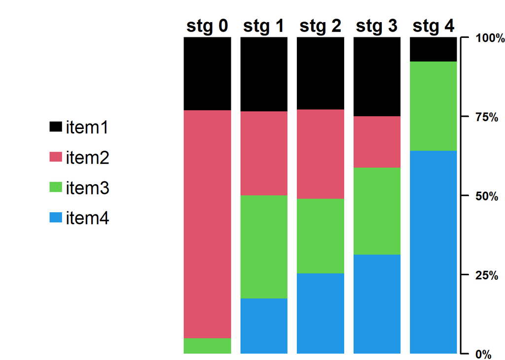

```r
# CUMULATIVE FISHER PERCENT
fisher_cum <- fisher[[2]]
for(i in 2:K.1)
  fisher_cum[i,] <- fisher_cum[i,] + fisher_cum[i-1,]

# GRAPH
par(mar=c(0.2,12,2.6,2.55))
barplot(height = fisher[[2]][K.1:1,], col = (1:K.1)[K.1:1], border = NA,
        xlab = "", axes = FALSE, axisnames = FALSE)

axis(4,line=-0.5,las=1,lwd=2, labels = c("0%","25%","50%","75%","100%"),at=c(0,25,50,75,100),cex.axis=1,font=2)
mtext(text = paste("stg ",0:4,sep=""), cex = 1.5,
      side = 3, line = 0.2, font = 2,
      at = 0.5+c(0.2,1.4,2.6,3.8,5))

par(xpd=TRUE)
legend(x = -3, y = 80,
       legend = paste("item",1:K.1,sep=""), fill = 1:K.1, border = F,
       bty = "n", cex = 1.5, y.intersp=1.4, x.intersp=0.2)
```

#### References

[1] SAULNIER, Tiphaine, MEISSNER, Wasslios G., LE GOFF, Mélanie, et al. Quality of Life evolution and associated factors in Multiple System Atrophy: an illustration for neurodegenerative diseases. 2023 [pre-print]

[2] REEVE, Bryce B., HAYS, Ron D., BJORNER, Jakob B., et al. Psychometric evaluation and calibration of health-related quality of life item banks: plans for the Patient-Reported Outcomes Measurement Information System (PROMIS). Medical care, 2007, p. S22-S31.

[3] LEE, Chun-Ting, ZHANG, Guangjian, et EDWARDS, Michael C. Ordinary least squares estimation of parameters in exploratory factor analysis with ordinal data. Multivariate Behavioral Research, 2012, vol. 47, no 2, p. 314-339.

[4] REVELLE, William. psych: Procedures for Psychological, Psychometric, and Personality Research. R package version 2.2.9, 2022, https://CRAN.R-project.org/package=psych.

[5] ROSSEEL, Yves, JORGENSEN, Terrence D., ROCKWOOK, Nicholas, et al. lavaan: Latent Variable Analysis. R package version 0.6-11, 2022, https://CRAN.R-project.org/package=lavaan

[6] VAN DER ARK, L. Andries, KOOPMAN, Letty, STRAAT, J. Hendrick, et al. mokken: Conducts Mokken Scale Analysis. R package version 3.0.6, 2021, https://CRAN.R-project.org/package=mokken

[7] SAULNIER, Tiphaine, PHILIPPS, Viviane, MEISSNER, Wassilios G., et al. Joint models for the longitudinal analysis of measurement scales in the presence of informative dropout. Methods, 2022, vol. 203, p. 142-151.

[8] PHILIPPS, Viviane, SAULNIER, Tiphaine, PROUST-LIMA, Cécile. JLPM: Joint Latent Process Models. R package version 1.0.1, 2022, https://CRAN.R-project.org/package=JLPM